# Data Analysis and Visualization of Anime data

The questions we will answer:

Which studio produces the most anime?

What are the top rated anime of all time?

Which studio produces the highest rated anime?

Which genre has the highest average rating?

Which release year had the highest rated anime?

Does episode count impact rating?

```python
import pandas as pd
import matplotlib.pyplot as plt
import seaborn as sns
import numpy as np

%matplotlib inline

# Load the dataset into a Pandas DataFrame
anime_data = pd.read_csv('Anime.csv',index_col=0)

anime_data.head()
```

| Rank | Name | Japanese_name | Type | Episodes | Studio | Release_season | Tags | Rating | Release_year | End_year | Description | Content_Warning | Related_Mange | Related_anime | Voice_actors | staff |
| --- | --- | --- | --- | --- | --- | --- | --- | --- | --- | --- | --- | --- | --- | --- | --- | --- |
| 1 | Demon Slayer: Kimetsu no Yaiba - Entertainment... | Kimetsu no Yaiba: Yuukaku-hen | TV | NaN | ufotable | Fall | Action, Adventure, Fantasy, Shounen, Demons, H... | 4.60 | 2021.0 | NaN | 'Tanjiro and his friends accompany the Hashira... | Explicit Violence | Demon Slayer: Kimetsu no Yaiba | Demon Slayer: Kimetsu no Yaiba, Demon Slayer: ... | Inosuke Hashibira : Yoshitsugu Matsuoka, Nezuk... | Koyoharu Gotouge : Original Creator, Haruo Sot... |
| 2 | Fruits Basket the Final Season | Fruits Basket the Final | TV | 13.0 | TMS Entertainment | Spring | Drama, Fantasy, Romance, Shoujo, Animal Transf... | 4.60 | 2021.0 | NaN | 'The final arc of Fruits Basket.' | Emotional Abuse,, Mature Themes,, Physical Abu... | Fruits Basket, Fruits Basket Another | Fruits Basket 1st Season, Fruits Basket 2nd Se... | Akito Sohma : Maaya Sakamoto, Kyo Sohma : Yuum... | Natsuki Takaya : Original Creator, Yoshihide I... |
| 3 | Mo Dao Zu Shi 3 | The Founder of Diabolism 3 | Web | 12.0 | B.C MAY PICTURES | NaN | Fantasy, Ancient China, Chinese Animation, Cul... | 4.58 | 2021.0 | NaN | 'The third season of Mo Dao Zu Shi.' | NaN | Grandmaster of Demonic Cultivation: Mo Dao Zu ... | Mo Dao Zu Shi 2, Mo Dao Zu Shi Q | Lan Wangji, Wei Wuxian, Jiang Cheng, Jin Guang... | Mo Xiang Tong Xiu : Original Creator, Xiong Ke... |
| 4 | Fullmetal Alchemist: Brotherhood | Hagane no Renkinjutsushi: Full Metal Alchemist | TV | 64.0 | Bones | Spring | Action, Adventure, Drama, Fantasy, Mystery, Sh... | 4.58 | 2009.0 | 2010.0 | "The foundation of alchemy is based on the law... | Animal Abuse,, Mature Themes,, Violence,, Dome... | Fullmetal Alchemist, Fullmetal Alchemist (Ligh... | Fullmetal Alchemist: Brotherhood Specials, Ful... | Alphonse Elric : Rie Kugimiya, Edward Elric : ... | Hiromu Arakawa : Original Creator, Yasuhiro Ir... |
| 5 | Attack on Titan 3rd Season: Part II | Shingeki no Kyojin Season 3: Part II | TV | 10.0 | WIT Studio | Spring | Action, Fantasy, Horror, Shounen, Dark Fantasy... | 4.57 | 2019.0 | NaN | 'The battle to retake Wall Maria begins now! W... | Cannibalism,, Explicit Violence | Attack on Titan, Attack on Titan: End of the W... | Attack on Titan, Attack on Titan 2nd Season, A... | Armin Arlelt : Marina Inoue, Eren Jaeger : Yuu... | Hajime Isayama : Original Creator, Tetsurou Ar... |

This is the dataset we will work with. It contains all the anime on https://www.anime-planet.com/, a popular anime database. It lists the rank (by rating), English name, Japanese name, Type, Episodes, Studio, Release season, Genre tags, release year, end year, description, content warning, related manga, related anime, voice actors, and staff. We will use this information to draw results to common questions an anime enthusiast may have.

# Data cleaning

```python
anime_data = pd.read_csv('Anime.csv', index_col=0)

# Keep only the required columns
selected_columns = ['Name', 'Episodes', 'Studio', 'Tags', 'Rating', 'Release_year']
anime_data_cleaned = anime_data[selected_columns]
anime_data = anime_data_cleaned

# Display the cleaned DataFrame
anime_data.head()
```

| Rank | Name | Episodes | Studio | Tags | Rating | Release_year |
| --- | --- | --- | --- | --- | --- | --- |
| 1 | Demon Slayer: Kimetsu no Yaiba - Entertainment... | NaN | ufotable | Action, Adventure, Fantasy, Shounen, Demons, H... | 4.60 | 2021.0 |
| 2 | Fruits Basket the Final Season | 13.0 | TMS Entertainment | Drama, Fantasy, Romance, Shoujo, Animal Transf... | 4.60 | 2021.0 |
| 3 | Mo Dao Zu Shi 3 | 12.0 | B.C MAY PICTURES | Fantasy, Ancient China, Chinese Animation, Cul... | 4.58 | 2021.0 |
| 4 | Fullmetal Alchemist: Brotherhood | 64.0 | Bones | Action, Adventure, Drama, Fantasy, Mystery, Sh... | 4.58 | 2009.0 |
| 5 | Attack on Titan 3rd Season: Part II | 10.0 | WIT Studio | Action, Fantasy, Horror, Shounen, Dark Fantasy... | 4.57 | 2019.0 |

# Which studio has produced the most anime?

```python
#Create a dataframe with studio name and number of anime it produced and release year.
anime_counts=anime_data.groupby(['Studio','Release_year']).size().reset_index(name='Anime_produced')
anime_counts
```

|  | Studio | Release_year | Anime_produced |
| --- | --- | --- | --- |
| 0 | 10GAUGE | 2014.0 | 1 |
| 1 | 10GAUGE | 2015.0 | 1 |
| 2 | 10GAUGE | 2016.0 | 1 |
| 3 | 10GAUGE | 2018.0 | 2 |
| 4 | 10GAUGE | 2021.0 | 1 |
| ... | ... | ... | ... |
| 3932 | ufotable | 2017.0 | 4 |
| 3933 | ufotable | 2018.0 | 1 |
| 3934 | ufotable | 2019.0 | 2 |
| 3935 | ufotable | 2020.0 | 2 |
| 3936 | ufotable | 2021.0 | 2 |

3937 rows × 3 columns

```python
#Create a dataframe with total anime produced by each studio.
studio_total=anime_counts.groupby('Studio')['Anime_produced'].sum().reset_index(name='Total anime')
#Top 10 studios with the most produced anime of all time
top_studio=studio_total.nlargest(10,'Total anime')
top_studio
```

|  | Studio | Total anime |
| --- | --- | --- |
| 640 | Toei Animation | 733 |
| 604 | Sunrise | 470 |
| 250 | J.C.Staff | 382 |
| 615 | TMS Entertainment | 364 |
| 311 | MADHOUSE | 355 |
| 417 | Production I.G | 279 |
| 524 | Studio DEEN | 278 |
| 462 | Shanghai Animation Film Studio | 250 |
| 359 | OLM | 249 |
| 403 | Pierrot | 240 |

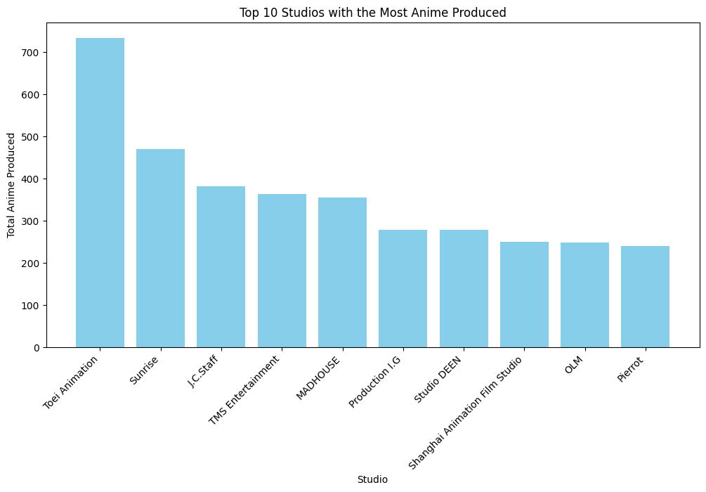

```python
# Plotting the top 10 studios with the most anime produced
plt.figure(figsize=(12, 6))
plt.bar(top_studio['Studio'], top_studio['Total anime'], color='skyblue')
plt.title('Top 10 Studios with the Most Anime Produced')
plt.xlabel('Studio')
plt.ylabel('Total Anime Produced')
plt.xticks(rotation=45, ha='right')
plt.show()
```

As we can see, Toei Animation blows every other studio out of the water when it comes to anime produced. This makes sense because Toei Animation was founded back in 1956, at the very start of the animation boom. They have stuck around for a long time with massive hits such as "Dragon Ball" and "One Piece".

# What are the top rated anime of all time?

```python
# Find the top-rated anime of all time
top_rated_anime_all_time = anime_data.nlargest(10, 'Rating')

# Display the top-rated anime
top_rated_anime_all_time[['Name', 'Rating']]
```

| Rank | Name | Rating |
| --- | --- | --- |
| 1 | Demon Slayer: Kimetsu no Yaiba - Entertainment... | 4.60 |
| 2 | Fruits Basket the Final Season | 4.60 |
| 3 | Mo Dao Zu Shi 3 | 4.58 |
| 4 | Fullmetal Alchemist: Brotherhood | 4.58 |
| 5 | Attack on Titan 3rd Season: Part II | 4.57 |
| 6 | Jujutsu Kaisen | 4.56 |
| 7 | Attack on Titan The Final Season: Part II | 4.56 |
| 8 | Attack on Titan The Final Season | 4.55 |
| 9 | Demon Slayer: Kimetsu no Yaiba Movie - Mugen T... | 4.54 |
| 10 | Haikyuu!! Karasuno High School vs Shiratorizaw... | 4.53 |

This table shows us that "Demon Slayer" is the top rated anime according to anime-planet users. On the list you can see other very popular shows such as "Fullmetal Alchemist", "Attack on Titan", and "Jujutsu Kaisen".

# Which studios make the highest rated anime on average?

```python
average_rating_by_studio = anime_data.groupby('Studio')['Rating'].mean().reset_index(name='Average_Rating')

# Rank studios by average rating
ranked_studios = average_rating_by_studio.sort_values(by='Average_Rating', ascending=False)

top_10_studios = ranked_studios.head(10)
top_10_studios
```

|  | Studio | Average_Rating |
| --- | --- | --- |
| 567 | Studio Pivote | 4.360000 |
| 640 | Tiger Animation | 4.350000 |
| 58 | B.C MAY PICTURES | 4.190000 |
| 341 | Mua Film | 4.160000 |
| 339 | Motion Magic | 4.142222 |
| 465 | Sharefun Studio | 4.125000 |
| 666 | V1 Studio | 4.046667 |
| 39 | Animation Do | 4.028889 |
| 392 | Paper Plane | 4.020000 |
| 517 | Studio Bind | 4.015000 |

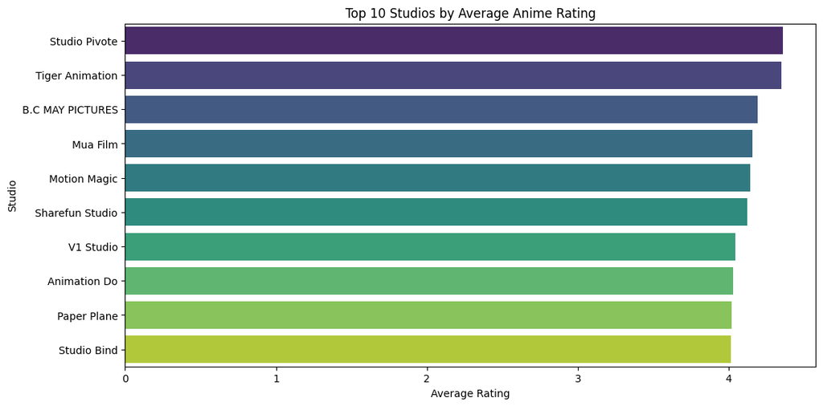

```python
plt.figure(figsize=(12, 6))
sns.barplot(x='Average_Rating', y='Studio', data=top_10_studios, palette='viridis')
plt.title('Top 10 Studios by Average Anime Rating')
plt.xlabel('Average Rating')
plt.ylabel('Studio')
plt.show()
```

It appears that Studio Pivote is the studio which has produced the highest quality anime, according to anime-planet users.

# Which genre has the highest average rating?

```python
genres_split = anime_data['Tags'].str.split(',').explode()

# Creating a DataFrame with the split genres
genres_df = pd.DataFrame({'Anime_ID': genres_split.index, 'Genre': genres_split.values})

# Merge the original DataFrame with the split genres DataFrame
anime_data_with_genres = pd.merge(anime_data, genres_df, left_index=True, right_on='Anime_ID')

# Now, 'Genre' is a separate column in the DataFrame
average_rating_by_genre = anime_data_with_genres.groupby('Genre')['Rating'].mean().reset_index(name='Average_Rating')

# Find the genre with the highest average rating
highest_rated_genre = average_rating_by_genre.loc[average_rating_by_genre['Average_Rating'].idxmax()]

# Display the genre with the highest average rating
print("Genre with the Highest Average Rating:")
print(highest_rated_genre)
```

```
Genre with the Highest Average Rating:
Genre              Dysfunctional Families
Average_Rating                   4.225714
Name: 177, dtype: object
```

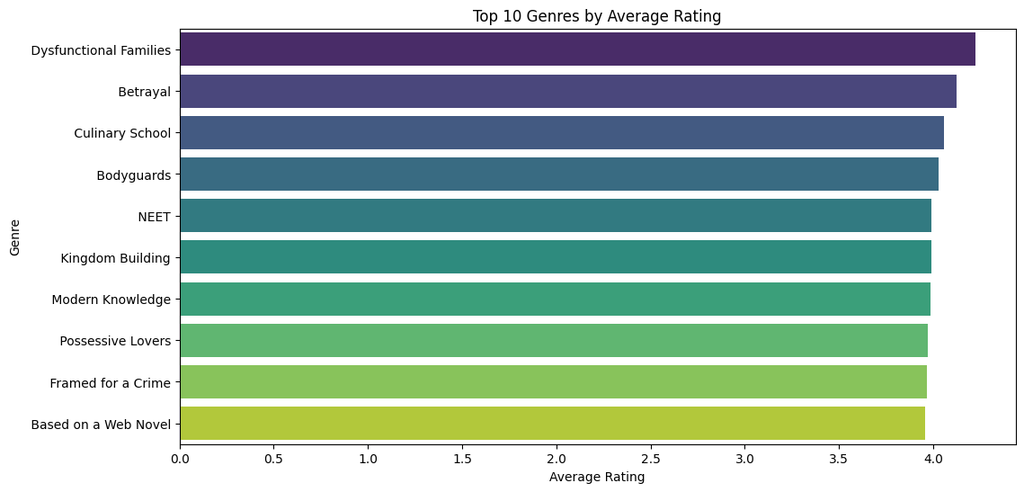

```python
top_10_genres = average_rating_by_genre.nlargest(10, 'Average_Rating')

# Visualize the top 10 genres
plt.figure(figsize=(12, 6))
sns.barplot(x='Average_Rating', y='Genre', data=top_10_genres, palette='viridis')
plt.title('Top 10 Genres by Average Rating')
plt.xlabel('Average Rating')
plt.ylabel('Genre')
plt.show()
```

With genres like "Dysfunctional families", "Betrayal", "Possessive lovers", and "Framed for a crime" all with very high ratings, it seems the average anime fan enjoys stories with a lot of drama and stakes.

# Which year released the highest rated anime on average?

```python
# Assuming 'Release_year' is a column in your 'anime_data' DataFrame
average_rating_by_year = anime_data.groupby('Release_year')['Rating'].mean().reset_index(name='Average_Rating')

# Find the year with the highest average rating
highest_rated_year = average_rating_by_year.loc[average_rating_by_year['Average_Rating'].idxmax()]

# Display the year with the highest average rating
print("Year with the Highest Average Rating:")
print(highest_rated_year)
```

```
Year with the Highest Average Rating:
Release_year      1955.00
Average_Rating       3.62
Name: 34, dtype: float64
```

```python
# Assuming 'Release_year' is a column in your 'anime_data' DataFrame
average_rating_by_year = anime_data.groupby('Release_year')['Rating'].mean().reset_index(name='Average_Rating')

# Find the top 10 years by average rating
top_10_years = average_rating_by_year.nlargest(10, 'Average_Rating')

# Display the top 10 years in a table
top_10_years
```

|  | Release_year | Average_Rating |
| --- | --- | --- |
| 34 | 1955.0 | 3.620000 |
| 101 | 2022.0 | 3.609167 |
| 100 | 2021.0 | 3.570905 |
| 99 | 2020.0 | 3.496601 |
| 98 | 2019.0 | 3.457572 |
| 87 | 2008.0 | 3.432967 |
| 2 | 1918.0 | 3.430000 |
| 97 | 2018.0 | 3.418150 |
| 86 | 2007.0 | 3.413325 |
| 57 | 1978.0 | 3.400408 |

With the exception of 1955, it seems that modern anime are generally the highest rated according to users. This is likely due to many users not having seen older shows so modern shows have the advantage here.

# What is the most prefered episode count for viewers?

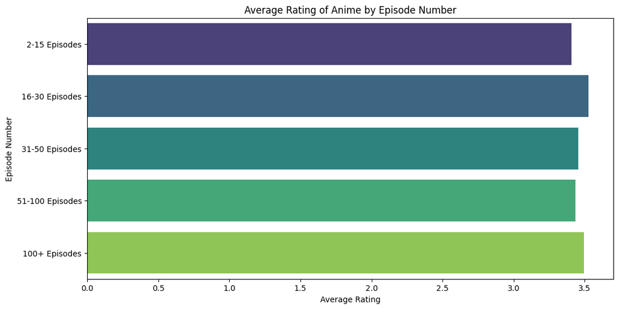

```python
# Create a new column 'Episode_Category' based on the specified ranges
bins = [2, 15, 30, 50, 100, np.inf]
labels = ['2-15 Episodes', '16-30 Episodes', '31-50 Episodes', '51-100 Episodes', '100+ Episodes']
anime_data['Episode_Category'] = pd.cut(anime_data['Episodes'], bins=bins, labels=labels, right=False)

# Calculate the average rating for each episode category
average_rating_by_episode_category = anime_data.groupby('Episode_Category')['Rating'].mean().reset_index(name='Average_Rating')

# Visualize the average ratings for each episode category
plt.figure(figsize=(12, 6))
sns.barplot(x='Average_Rating', y='Episode_Category', data=average_rating_by_episode_category, palette='viridis')
plt.title('Average Rating of Anime by Episode Number')
plt.xlabel('Average Rating')
plt.ylabel('Episode Number')
plt.show()
```

There doesn't seem to be much conclusions we can draw from here since they are all so close, but one conclusion we can draw is that longer episode counts do not show a decrease in rating. It seems users are not drawn away by longer series.